### Changing the colour of the whole plot or its outline

To colour your entire plot one colour, add `fill = "colour"` or `colour = "colour"` into the brackets following the `geom_...` code where you specified what type of graph you want.

Note that for most plots, `fill = "colour"` will colour the whole shape, whereas `colour = "colour"` will fill in the outline.

For example, to make a blue box plot with a red outline, or a yellow histogram with an green outline::

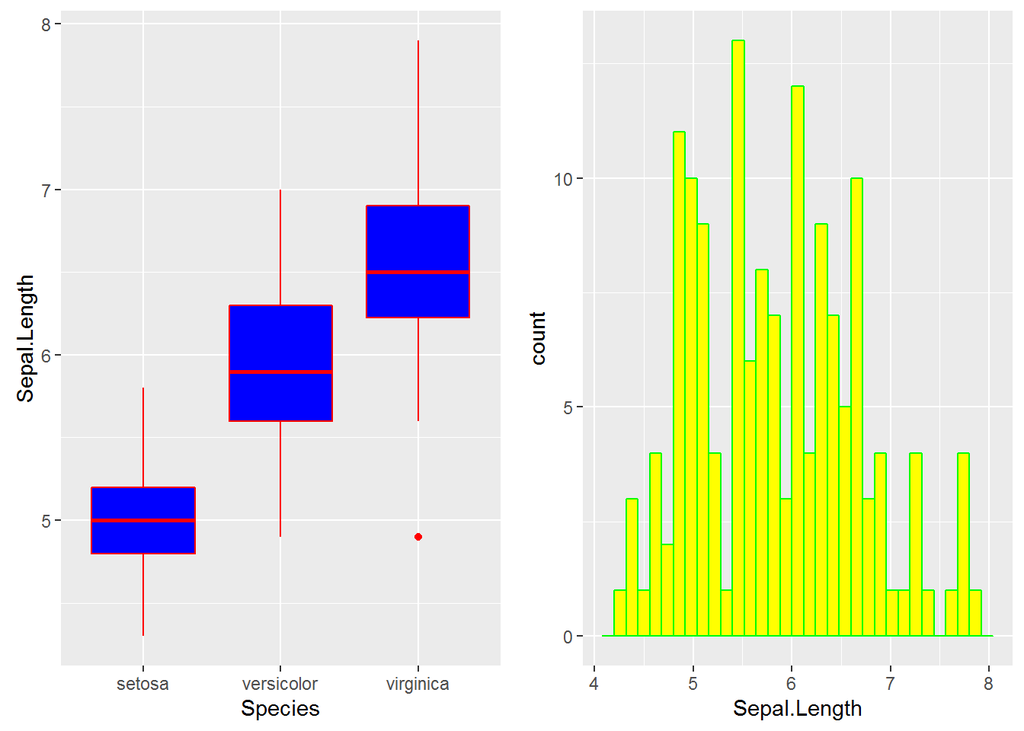

```r
IrisBox <- ggplot(iris, aes(Species, Sepal.Length)) + geom_boxplot(fill = "blue", colour = "red")

IrisHist <- ggplot(iris, aes(Sepal.Length)) + geom_histogram(fill = "yellow", colour = "green")
```

For scatterplots, `colour = "colour"` will specify the fill colour for the point shape.

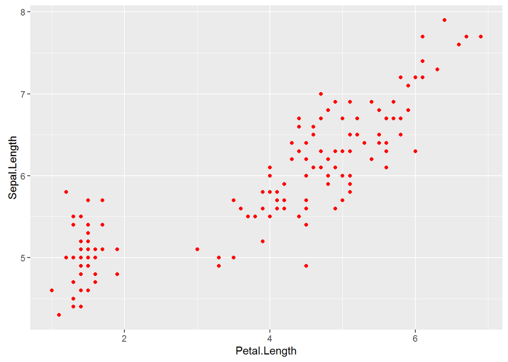

```r
IrisPlot <- ggplot(iris, aes(Petal.Length, Sepal.Length)) + geom_point(colour = "red")
```

The plots and outlines can be changed to any colour listed [here](http://www.stat.columbia.edu/~tzheng/files/Rcolor.pdf). Remember to include “” before and after the colour name.

### Using colour to visualise additional variables

**Additional categorical variables**

If you wish to colour point on a **scatter plot** by a third categorical variable, then add `colour = variable.name` within your `aes` brackets. This tells ggplot that this third variable will colour the points. To colour the points by the variable Species:

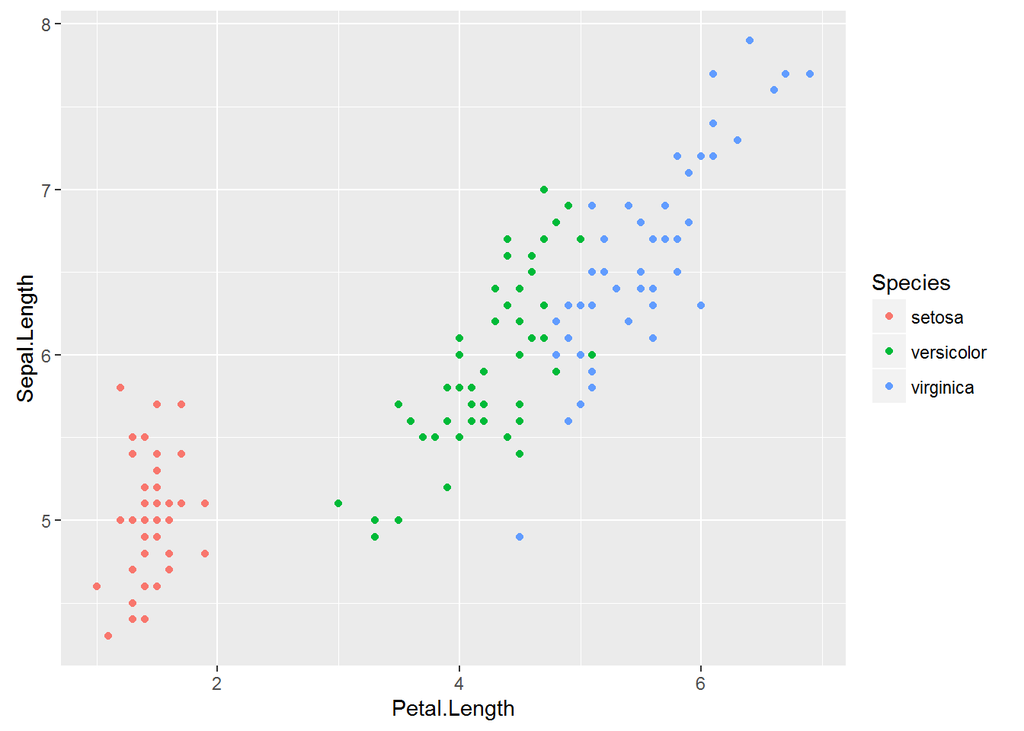

```r
IrisPlot <- ggplot(iris, aes(Petal.Length, Sepal.Length, colour = Species)) + geom_point()
```

To colour **box plots** or **bar plots** by a given categorical variable, you use you use `fill = variable.name` instead of `colour`.

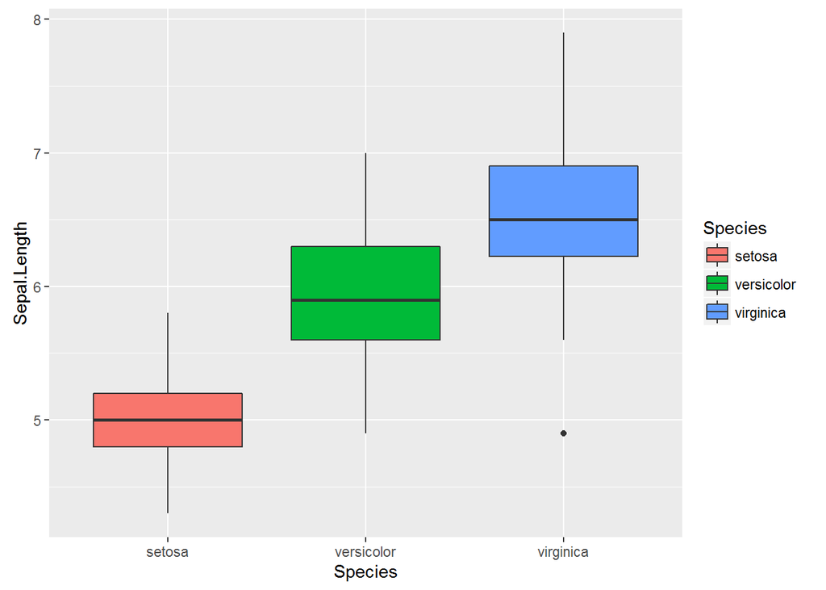

```r
IrisBox <- ggplot(iris, aes(Species, Sepal.Length, fill = Species)) + geom_boxplot()
```

**Additional continuous variable**

The basic format for colouring a continuous variable is very similar to a categorical variable. The only real difference is you need to use `+ scale_colour_gradient(low = "colour1", high = "colour2")`. The other colour scales will not work as they are for categorical variables. For example, here is a plot of sepal length vs petal length, with the symbols colored by their value of sepal width.

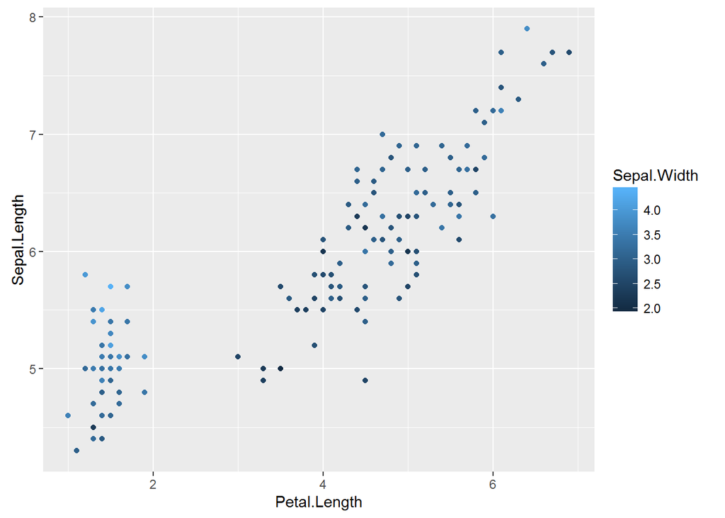

```r
IrisPlot.continuous <- ggplot(iris, aes(Petal.Length, Sepal.Length, colour = Sepal.Width)) + geom_point()

print(IrisPlot.continuous)
```

To make the gradient more effective, specify two colours within the `+ scale_colour_gradient` brackets to represent either end of the gradient. For example:

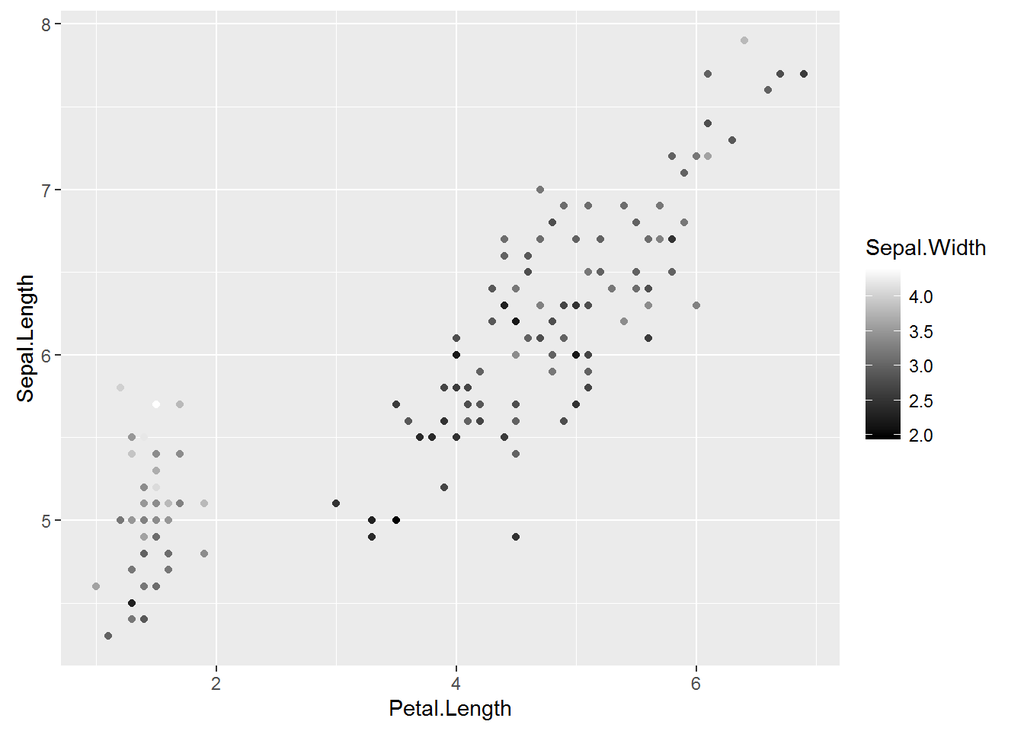

```r
print(IrisPlot.continuous + scale_colour_gradient(low = "black", high = "white"))
```

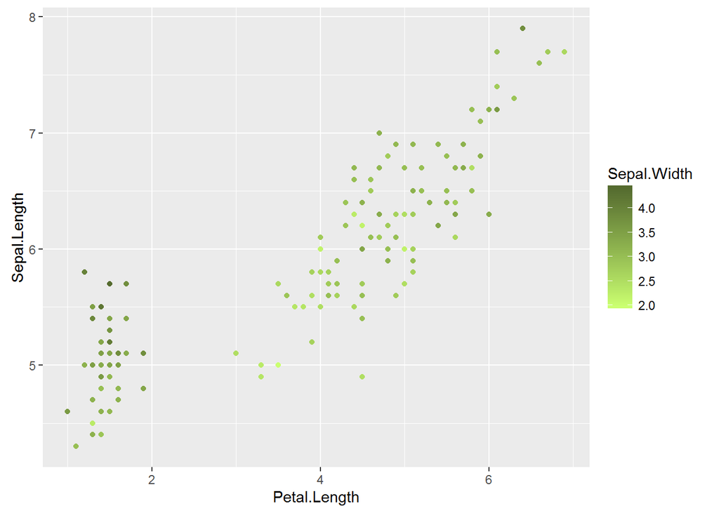

```r
print(IrisPlot.continuous + scale_colour_gradient(low = "darkolivegreen1", high = "darkolivegreen"))
```

### Choosing your own colours for these variables

This can be done in numerous ways. The basic format is to add `+ scale_colour_yourchoice()` for scatter plots or `+ scale_fill_yourchoice()` for box plots to the code where you ‘print’ your graph, where `yourchoice()` is one of several options. The syntax is:

`print(your.basic.graph + your.theme + scale_colour_yourchoice())`

There are numerous options for the `+ scale_colour_yourchoice()` part.

**Individually select colours.** To manually choose colours, you can use `+ scale_colour_manual()` or `+ scale_fill_manual()`. For example, to choose three colours for the iris plots:

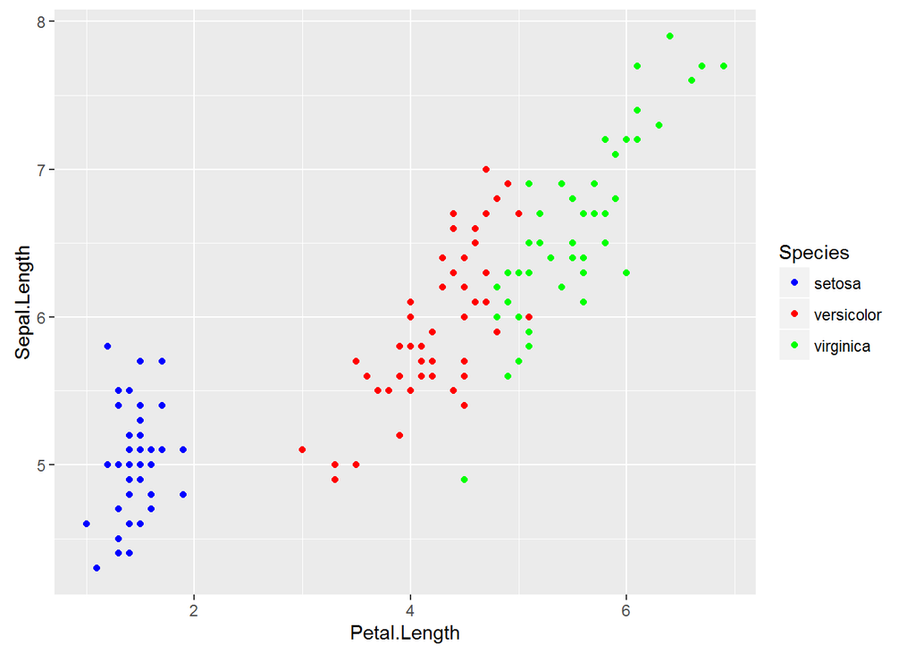

```r
print(IrisPlot + scale_colour_manual(values = c("Blue", "Red", "Green")))
```

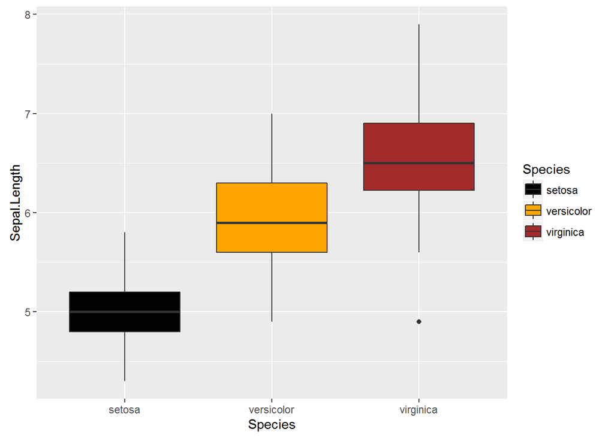

```r
print(IrisBox + scale_fill_manual(values = c("Black", "Orange", "Brown")))
```

**Assign tones on a greyscale.** Use `+ scale_colour_grey()` or `+ scale_fill_grey()`

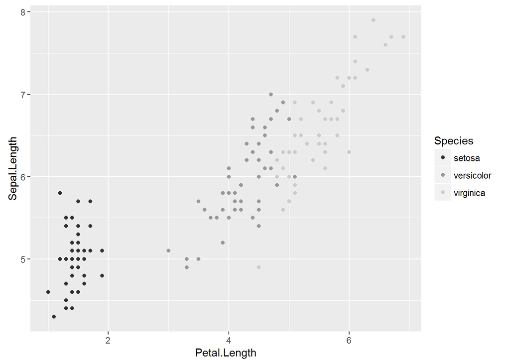

```r
print(IrisPlot + scale_colour_grey())
```

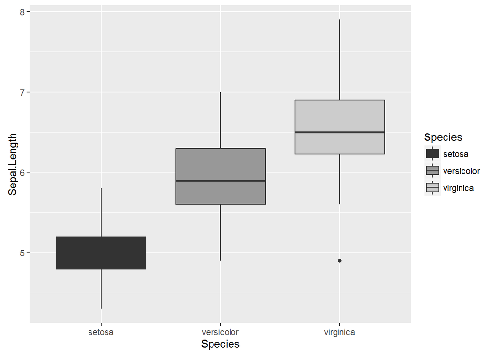

```r
print(IrisBox + scale_fill_grey())
```

**Assign colours from a pre-made pallette.** Use `+ scale_colour_brewer()` or `+ scale_fill_brewer`. To do this you will need to install the package [RColorBrewer](https://cran.r-project.org/web/packages/RColorBrewer/index.html) and load in R.

```r
library(RColorBrewer)
```

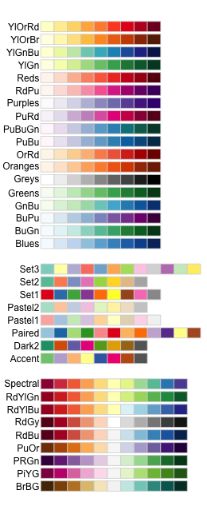

This can then be added to the end of your graph code just like the others `+ scale_colour_brewer(palette = "chosen.palette")` for scatterplots and `+ scale_fill_brewer(palette = "chosen.palette")` for boxplots, where `"chosen.pallete"` is one of the available palletes. For example,

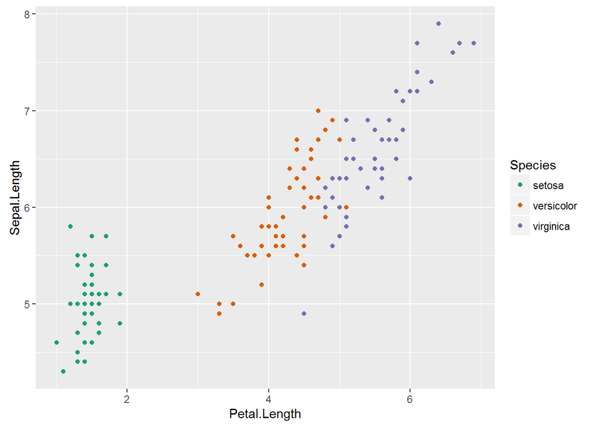

```r
print(IrisPlot + scale_colour_brewer(palette = "Dark2"))
```

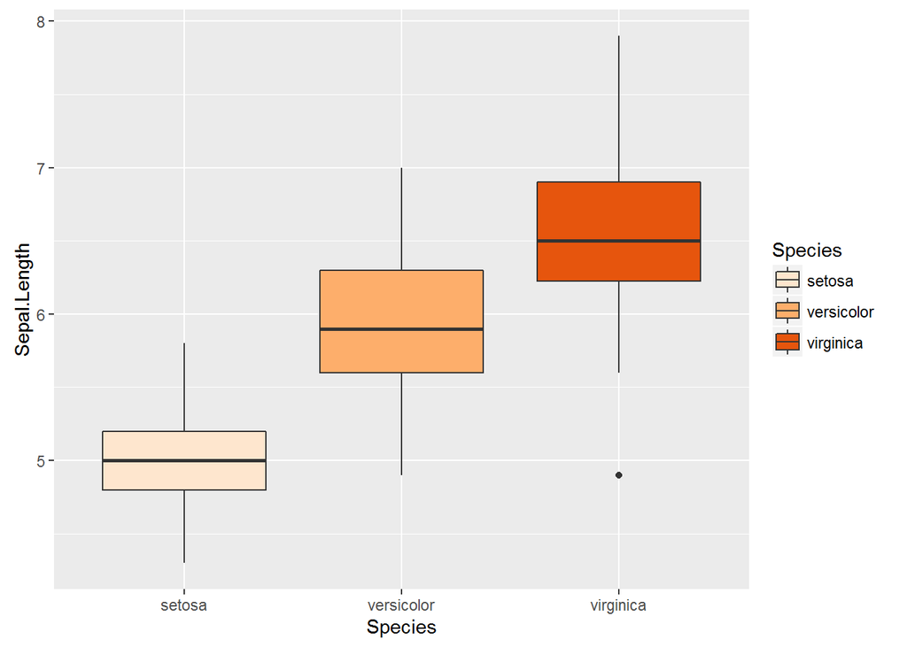

```r
print(IrisBox+ scale_fill_brewer(palette = "Oranges"))
```

### Changing symbols in a scatterplot

In a simple scatterplot with no grouping variables, you can change the shape of the symbol by adding `shape = ?` to the `geom_point()` code, where ? is one of the following numbers for different shapes.

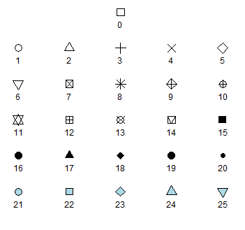

For example, to use a filled triangle,

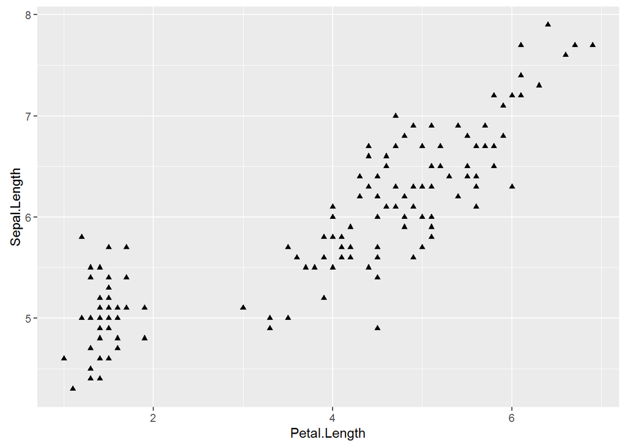

```r
IrisPlot <- ggplot(iris, aes(Petal.Length, Sepal.Length)) + geom_point(shape = 17)
```

Different symbols can be used to group data in a scatterplot. This can be very helpful when printing in black and white or to further distinguish your categories.

To do this, you need to add `shape = variable.name` within your basic plot `aes` brackets, where `variable.name` is the name of your grouping variable. For example, to have different symbols for each species, we would use.

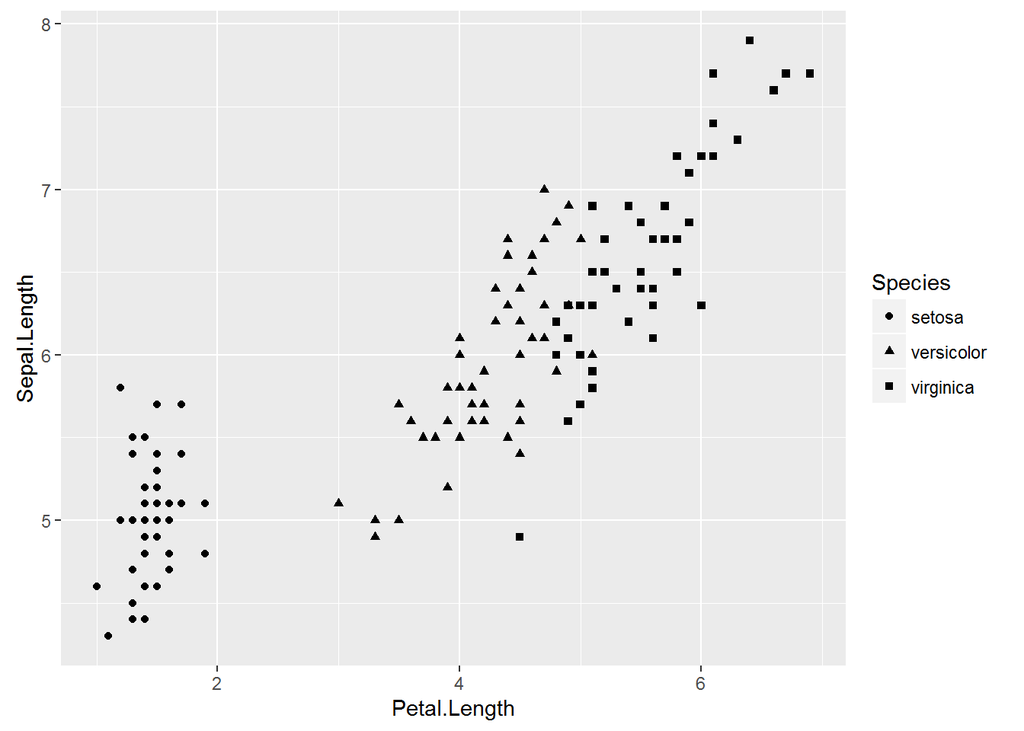

```r
IrisPlot.shape <- ggplot(iris, aes(Petal.Length, Sepal.Length, shape = Species)) + geom_point()
```

To set the symbols manually, we can use the symbol codes in `scale_shape_manual()` added to your print function.

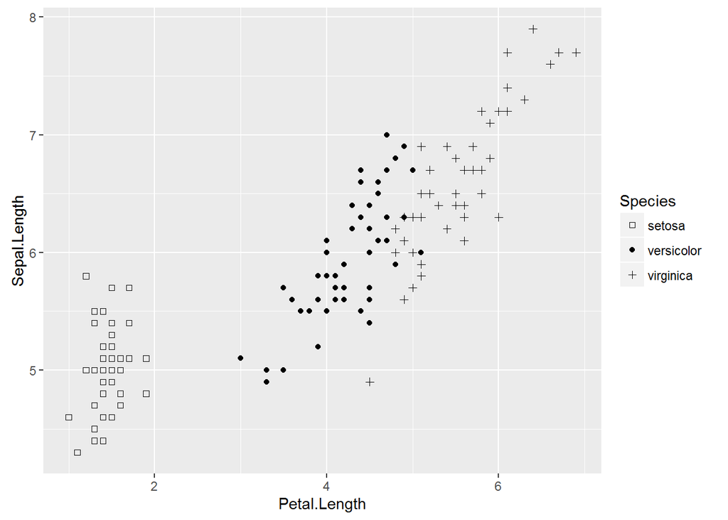

```r
print(IrisPlot.shape + scale_shape_manual(values = c(0, 16, 3)))
```

This can be used with colour to further distinguish and group your variables.

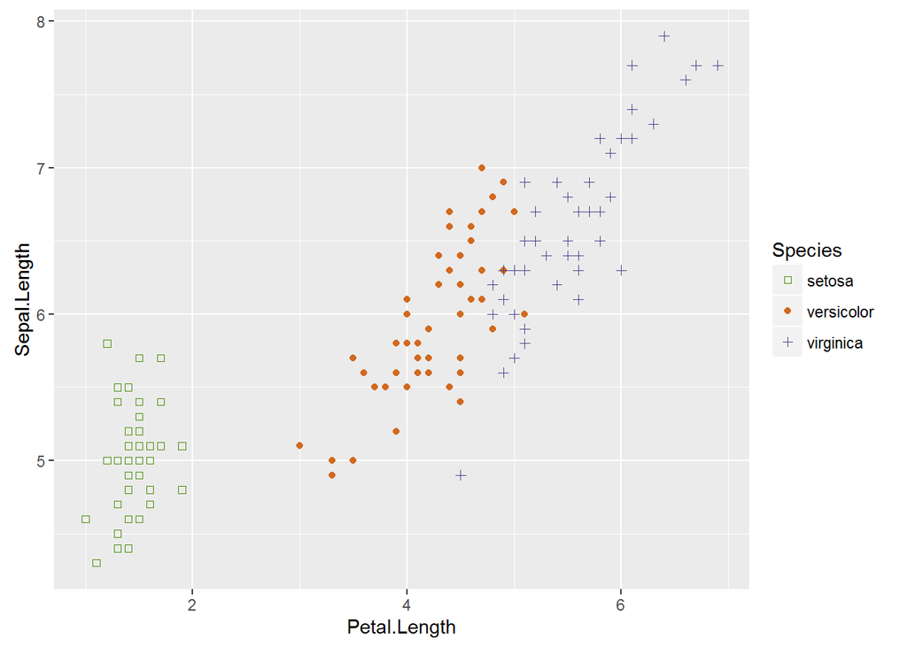

```r
IrisPlot.shape <- ggplot(iris, aes(Petal.Length, Sepal.Length, shape = Species, colour = Species)) + geom_point()

print(IrisPlot.shape + scale_shape_manual(values = c(0, 16, 3)) + scale_colour_manual(values = c("chartreuse4", "chocolate", "slateblue4")))
```

### Further help

To further customise the aesthetics of the graph, including colour and formatting, see our other ggplot help pages:  
*[altering overall appearance](http://environmentalcomputing.net/plotting-with-ggplot-altering-the-overall-appearance/).*  
[adding titles and axis names](http://environmentalcomputing.net/plotting-with-ggplot-adding-titles-and-axis-names/)

Help on all the ggplot functions can be found at the [The master ggplot help site](http://docs.ggplot2.org/current/).

A useful cheat sheet on commonly used functions can be downloaded [here](https://www.rstudio.com/wp-content/uploads/2015/03/ggplot2-cheatsheet.pdf).

Chang, W (2012) *R Graphics cookbook.* O’Reilly Media. - a guide to ggplot with quite a bit of help online [here](http://www.cookbook-r.com/Graphs/)

**Author**: Fiona Robinson  
Last updated:

```
## [1] "Tue May 24 10:52:52 2016"
```